# Assignment - Term Deposit Sale

### Importing all necessary modules

```python
import numpy as np
import pandas as pd

import matplotlib.pyplot as plt
import seaborn as sns
import pandas_profiling

from sklearn.model_selection import train_test_split
from sklearn.tree import DecisionTreeClassifier
from sklearn.metrics import accuracy_score, f1_score, recall_score, precision_score, confusion_matrix

from yellowbrick.classifier import ClassificationReport, ROCAUC

plt.style.use('ggplot')
pd.options.display.float_format = '{:,.4f}'.format
import warnings
warnings.filterwarnings('ignore')
```

### Importing data from csv file

```python
df_bank = pd.read_csv('bank-full.csv', sep=',')
```

```python
df_bank.head()
```

|  | age | job | marital | education | default | balance | housing | loan | contact | day | month | duration | campaign | pdays | previous | poutcome | Target |
| --- | --- | --- | --- | --- | --- | --- | --- | --- | --- | --- | --- | --- | --- | --- | --- | --- | --- |
| 0 | 58 | management | married | tertiary | no | 2143 | yes | no | unknown | 5 | may | 261 | 1 | -1 | 0 | unknown | no |
| 1 | 44 | technician | single | secondary | no | 29 | yes | no | unknown | 5 | may | 151 | 1 | -1 | 0 | unknown | no |
| 2 | 33 | entrepreneur | married | secondary | no | 2 | yes | yes | unknown | 5 | may | 76 | 1 | -1 | 0 | unknown | no |
| 3 | 47 | blue-collar | married | unknown | no | 1506 | yes | no | unknown | 5 | may | 92 | 1 | -1 | 0 | unknown | no |
| 4 | 33 | unknown | single | unknown | no | 1 | no | no | unknown | 5 | may | 198 | 1 | -1 | 0 | unknown | no |

### Checking for null values

```python
df_bank.isnull().any()
```

```
age          False
job          False
marital      False
education    False
default      False
balance      False
housing      False
loan         False
contact      False
day          False
month        False
duration     False
campaign     False
pdays        False
previous     False
poutcome     False
Target       False
dtype: bool
```

No null values so no action required on this front

Checking count of unknowns in columns job, education, contact, poutcome

```python
print("***JOB***")
print(df_bank.job.value_counts())
print("***EDUCATION***")
print(df_bank.education.value_counts())
print("***CONTACT***")
print(df_bank.contact.value_counts())
print("***POUTCOME***")
print(df_bank.poutcome .value_counts())
```

```
***JOB***
blue-collar      9732
management       9458
technician       7597
admin.           5171
services         4154
retired          2264
self-employed    1579
entrepreneur     1487
unemployed       1303
housemaid        1240
student           938
unknown           288
Name: job, dtype: int64
***EDUCATION***
secondary    23202
tertiary     13301
primary       6851
unknown       1857
Name: education, dtype: int64
***CONTACT***
cellular     29285
unknown      13020
telephone     2906
Name: contact, dtype: int64
***POUTCOME***
unknown    36959
failure     4901
other       1840
success     1511
Name: poutcome, dtype: int64
```

```python
print(f'job unknowns = {df_bank[df_bank["job"]=="unknown"].job.count()}')
print(f'education unknowns = {df_bank[df_bank["education"]=="unknown"].job.count()}')
print(f'contact unknowns = {df_bank[df_bank["contact"]=="unknown"].job.count()}')
print(f'poutcome unknowns = {df_bank[df_bank["poutcome"]=="unknown"].job.count()}')
```

```
job unknowns = 288
education unknowns = 1857
contact unknowns = 13020
poutcome unknowns = 36959
```

Insights: jobs unknown should not have a big effect on the data as the number is relatively small contact is something we possibly could ignore education and poutcome is something that we would need to re-visit later to see if something can be changed. Please note this is the phase where I am speculating if data needs to be modified/ dropped but irrespective the first go will be with all data unless dropping or changing data is absolutely evident.

### Checking nature of data

```python
df_bank.info();
```

```
<class 'pandas.core.frame.DataFrame'>
RangeIndex: 45211 entries, 0 to 45210
Data columns (total 17 columns):
age          45211 non-null int64
job          45211 non-null object
marital      45211 non-null object
education    45211 non-null object
default      45211 non-null object
balance      45211 non-null int64
housing      45211 non-null object
loan         45211 non-null object
contact      45211 non-null object
day          45211 non-null int64
month        45211 non-null object
duration     45211 non-null int64
campaign     45211 non-null int64
pdays        45211 non-null int64
previous     45211 non-null int64
poutcome     45211 non-null object
Target       45211 non-null object
dtypes: int64(7), object(10)
memory usage: 5.9+ MB
```

Insights: Columns such as job, marital, education, default, housing , loan, contact, poutcome look like categories to me and would potentially require one-hot encoding

```python
df_bank.shape
```

```
(45211, 17)
```

```python
df_bank.describe()
```

|  | age | balance | day | duration | campaign | pdays | previous |
| --- | --- | --- | --- | --- | --- | --- | --- |
| count | 45,211.0000 | 45,211.0000 | 45,211.0000 | 45,211.0000 | 45,211.0000 | 45,211.0000 | 45,211.0000 |
| mean | 40.9362 | 1,362.2721 | 15.8064 | 258.1631 | 2.7638 | 40.1978 | 0.5803 |
| std | 10.6188 | 3,044.7658 | 8.3225 | 257.5278 | 3.0980 | 100.1287 | 2.3034 |
| min | 18.0000 | -8,019.0000 | 1.0000 | 0.0000 | 1.0000 | -1.0000 | 0.0000 |
| 25% | 33.0000 | 72.0000 | 8.0000 | 103.0000 | 1.0000 | -1.0000 | 0.0000 |
| 50% | 39.0000 | 448.0000 | 16.0000 | 180.0000 | 2.0000 | -1.0000 | 0.0000 |
| 75% | 48.0000 | 1,428.0000 | 21.0000 | 319.0000 | 3.0000 | -1.0000 | 0.0000 |
| max | 95.0000 | 102,127.0000 | 31.0000 | 4,918.0000 | 63.0000 | 871.0000 | 275.0000 |

```python
df_bank.median() #Finding median
```

```
age         39.0000
balance    448.0000
day         16.0000
duration   180.0000
campaign     2.0000
pdays       -1.0000
previous     0.0000
dtype: float64
```

Insights: The -1 in pdays needs to be handled as this would not give the correct picture, I plan to change all the -1s to 901 considering -1 denotes more than 900 days of contact. Now it could be much more than 900 days but considering a marketing campaign, 900 days is a considerable duration of time.

```python
# Replacing -1 with 901 for pdays
df_bank["pdays"] = df_bank.pdays.replace(-1, 901)
```

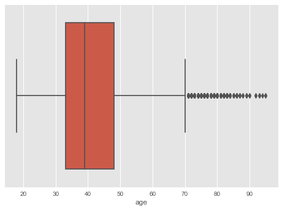

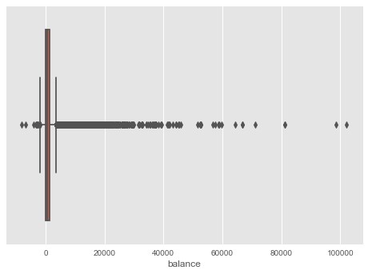

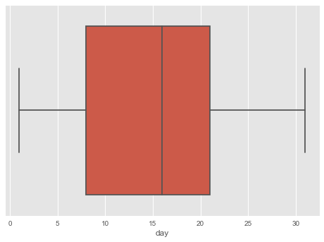

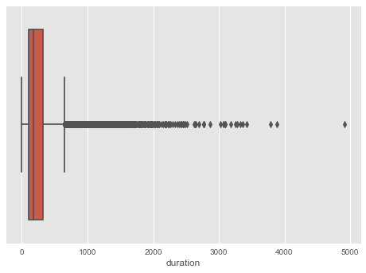

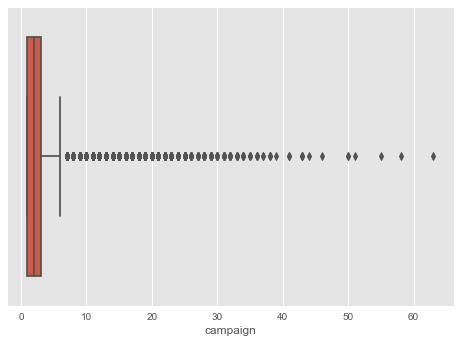

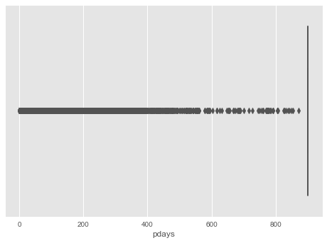

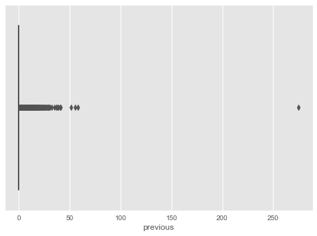

```python
# distplot for continous columns
for i in ['age','balance','day','duration','campaign','pdays','previous']:
    sns.boxplot(df_bank[i])
    plt.show()
```

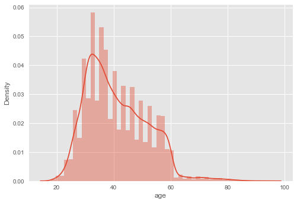

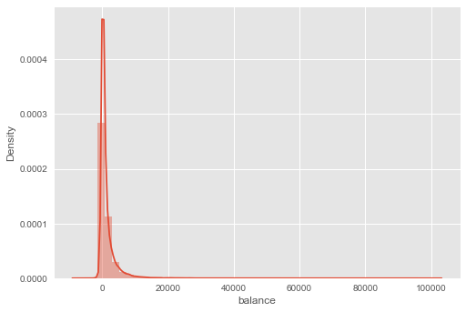

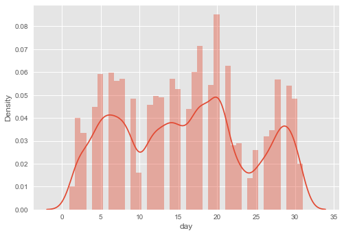

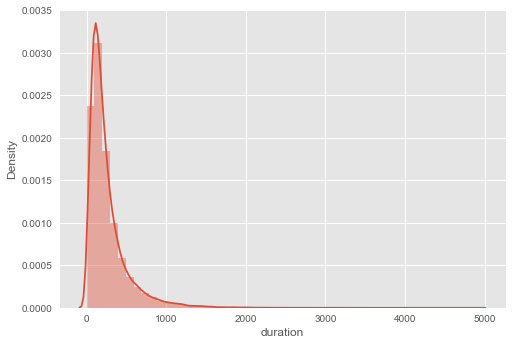

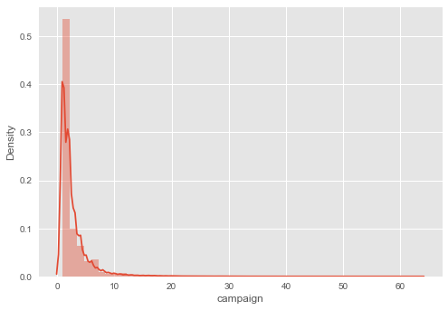

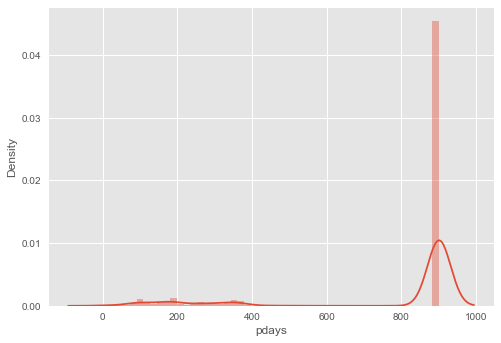

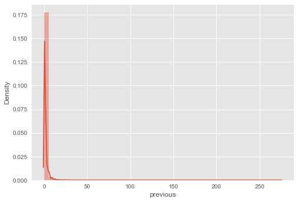

```python
# distplot for continous columns
for i in ['age','balance','day','duration','campaign','pdays','previous']:
    sns.distplot(df_bank[i])
    plt.show()
```

```python
for i in ['balance', 'duration', 'campaign']:
    print(i)
    print(df_bank[i].value_counts(normalize=True))
```

```
balance
0       0.0777
1       0.0043
2       0.0035
4       0.0031
3       0.0030
         ...
4305    0.0000
6352    0.0000
18881   0.0000
14889   0.0000
7218    0.0000
Name: balance, Length: 7168, dtype: float64
duration
124    0.0042
```

[output cut: 61 more lines]

```python
for i in ['pdays','previous']:
    print(df_bank[i].value_counts(normalize=True))
```

```
901   0.8174
182   0.0037
92    0.0033
91    0.0028
183   0.0028
       ...
749   0.0000
717   0.0000
589   0.0000
493   0.0000
32    0.0000
Name: pdays, Length: 559, dtype: float64
0     0.8174
1     0.0613
2     0.0466
```

[output cut: 39 more lines]

Insights: pdays and previous are highly skewed and are good candidates to be dropped.

```python
print("Continuous Variables","\n")
continous_vars=df_bank.describe().columns
print(continous_vars)

print("\n","Categorical Variables","\n")
categorical_vars=df_bank.describe(include=[object]).columns
print(categorical_vars)
```

```
Continuous Variables

Index(['age', 'balance', 'day', 'duration', 'campaign', 'pdays', 'previous'], dtype='object')

 Categorical Variables

Index(['job', 'marital', 'education', 'default', 'housing', 'loan', 'contact',
       'month', 'poutcome', 'Target'],
      dtype='object')
```

### Using correlation method to observe the relationship between different variables.

```python
df_bank.corr()
```

|  | age | balance | day | duration | campaign | pdays | previous |
| --- | --- | --- | --- | --- | --- | --- | --- |
| age | 1.0000 | 0.0978 | -0.0091 | -0.0046 | 0.0048 | -0.0099 | 0.0013 |
| balance | 0.0978 | 1.0000 | 0.0045 | 0.0216 | -0.0146 | -0.0383 | 0.0167 |
| day | -0.0091 | 0.0045 | 1.0000 | -0.0302 | 0.1625 | 0.0779 | -0.0517 |
| duration | -0.0046 | 0.0216 | -0.0302 | 1.0000 | -0.0846 | -0.0053 | 0.0012 |
| campaign | 0.0048 | -0.0146 | 0.1625 | -0.0846 | 1.0000 | 0.1081 | -0.0329 |
| pdays | -0.0099 | -0.0383 | 0.0779 | -0.0053 | 0.1081 | 1.0000 | -0.5272 |
| previous | 0.0013 | 0.0167 | -0.0517 | 0.0012 | -0.0329 | -0.5272 | 1.0000 |

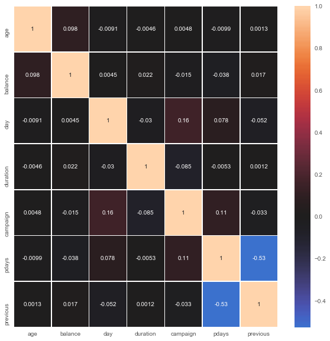

```python
plt.figure(figsize=(10,10))

ax_map = sns.heatmap(df_bank.corr(),
            annot=True,
            linewidths=.5,
            center=0,
            cbar=True)
ax_map.set_ylim(7.0, 0)

plt.show()
```

No strong correlation among the variables is seen among the continuous variables

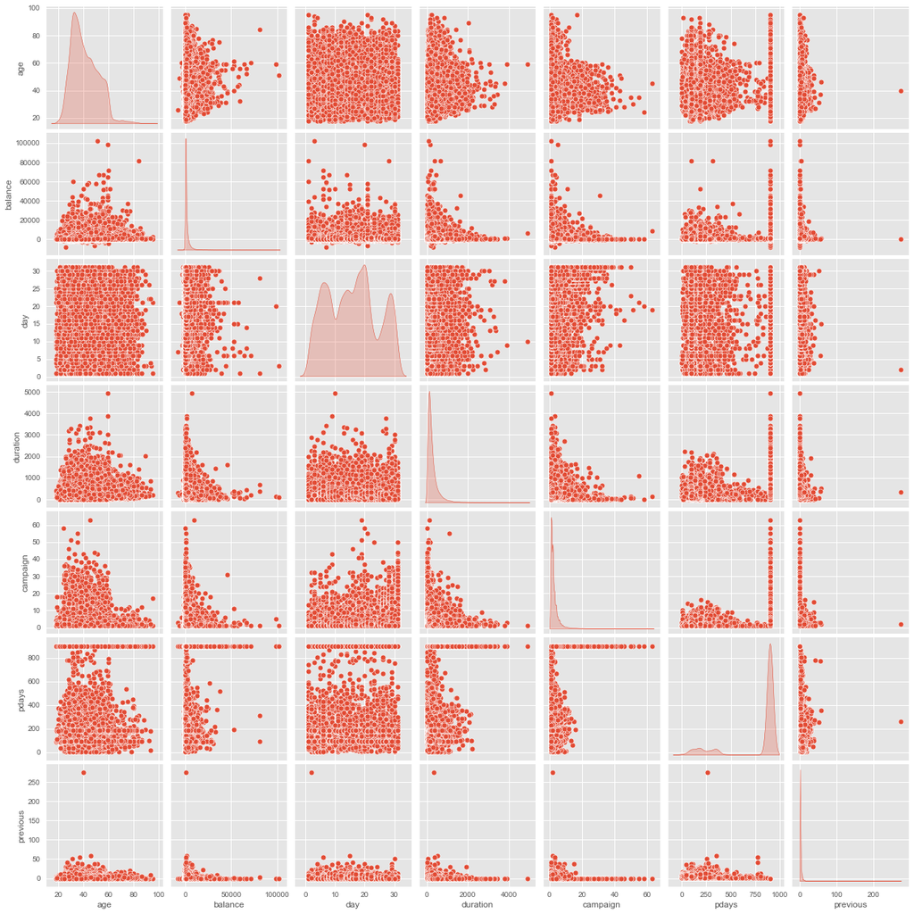

```python
sns.pairplot(df_bank,diag_kind='kde');
```

### Cleaning Data

Dropping columns

```python
df_mod = df_bank.drop (['pdays', 'previous'], axis=1)
```

Applying one-hot encoding

```python
df_mod = pd.get_dummies(df_mod, columns=['job', 'marital', 'education', 'month', 'default', 'housing' , 'loan', 'contact', 'poutcome'], drop_first=True)
```

```python
df_mod.head()
```

|  | age | balance | day | duration | campaign | Target | job_blue-collar | job_entrepreneur | job_housemaid | job_management | ... | month_oct | month_sep | default_yes | housing_yes | loan_yes | contact_telephone | contact_unknown | poutcome_other | poutcome_success | poutcome_unknown |
| --- | --- | --- | --- | --- | --- | --- | --- | --- | --- | --- | --- | --- | --- | --- | --- | --- | --- | --- | --- | --- | --- |
| 0 | 58 | 2143 | 5 | 261 | 1 | no | 0 | 0 | 0 | 1 | ... | 0 | 0 | 0 | 1 | 0 | 0 | 1 | 0 | 0 | 1 |
| 1 | 44 | 29 | 5 | 151 | 1 | no | 0 | 0 | 0 | 0 | ... | 0 | 0 | 0 | 1 | 0 | 0 | 1 | 0 | 0 | 1 |
| 2 | 33 | 2 | 5 | 76 | 1 | no | 0 | 1 | 0 | 0 | ... | 0 | 0 | 0 | 1 | 1 | 0 | 1 | 0 | 0 | 1 |
| 3 | 47 | 1506 | 5 | 92 | 1 | no | 1 | 0 | 0 | 0 | ... | 0 | 0 | 0 | 1 | 0 | 0 | 1 | 0 | 0 | 1 |
| 4 | 33 | 1 | 5 | 198 | 1 | no | 0 | 0 | 0 | 0 | ... | 0 | 0 | 0 | 0 | 0 | 0 | 1 | 0 | 0 | 1 |

5 rows × 41 columns

```python
df_mod["Target"] = df_mod["Target"].replace({'no':0, 'yes':1})
```

### Spliting Data

```python
# splitting data into training and test set for independent attributes
from sklearn.model_selection import train_test_split

features = [col for col in df_mod.columns if col != 'Target']

X_train, X_test, y_train, y_test = train_test_split(df_mod[features], df_mod['Target'], test_size=.3, random_state=22)
X_train.shape, X_test.shape
```

```
((31647, 40), (13564, 40))
```

### Applying Logistic Regression

```python
from sklearn.metrics import confusion_matrix, recall_score, precision_score, f1_score, roc_auc_score,accuracy_score
from sklearn.linear_model import LogisticRegression

logreg = LogisticRegression(random_state=42,fit_intercept=False)
logreg.fit(X_train, y_train)                    # fit the model on train data
```

```
LogisticRegression(C=1.0, class_weight=None, dual=False, fit_intercept=False,
          intercept_scaling=1, max_iter=100, multi_class='warn',
          n_jobs=None, penalty='l2', random_state=42, solver='warn',
          tol=0.0001, verbose=0, warm_start=False)
```

```python
y_predict = logreg.predict(X_test)
```

```python
## function to get confusion matrix in a proper format
def draw_cm( actual, predicted ):
    cm = confusion_matrix( actual, predicted)
    ax_map = sns.heatmap(cm, annot=True,  fmt='.2f', xticklabels = [0,1] , yticklabels = [0,1] )
    ax_map.set_ylim(2.0, 0)
    plt.ylabel('Observed')
    plt.xlabel('Predicted')
    plt.show()
```

```
Trainig accuracy 0.9023604133093184

Testing accuracy 0.8991447950457092

Confusion Matrix
```

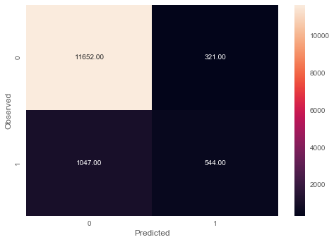

```
None

Recall: 0.3419233186675047

Precision: 0.6289017341040463

F1 Score: 0.44299674267100975

Roc Auc Score: 0.6575564977201218
```

```python
print("Trainig accuracy",logreg.score(X_train,y_train))
print()
print("Testing accuracy",logreg.score(X_test, y_test))
print()
print('Confusion Matrix')
print(draw_cm(y_test,y_predict))
print()
print("Recall:",recall_score(y_test,y_predict))
print()
print("Precision:",precision_score(y_test,y_predict))
print()
print("F1 Score:",f1_score(y_test,y_predict))
print()
print("Roc Auc Score:",roc_auc_score(y_test,y_predict))
```

```python
#Store the accuracy results for each model in a dataframe for final comparison
resultsDf = pd.DataFrame({'Method':['Logistic Regression'], 'accuracy': logreg.score(X_test, y_test), 'precision': precision_score(y_test,y_predict), 'recall': recall_score(y_test,y_predict)})
resultsDf = resultsDf[['Method', 'accuracy', 'precision', 'recall']]
resultsDf
```

|  | Method | accuracy | precision | recall |
| --- | --- | --- | --- | --- |
| 0 | Logistic Regression | 0.8991 | 0.6289 | 0.3419 |

### Decision Tree

```python
model_entropy = DecisionTreeClassifier(criterion='entropy')
```

```python
model_entropy.fit(X_train, y_train)
```

```
DecisionTreeClassifier(class_weight=None, criterion='entropy', max_depth=None,
            max_features=None, max_leaf_nodes=None,
            min_impurity_decrease=0.0, min_impurity_split=None,
            min_samples_leaf=1, min_samples_split=2,
            min_weight_fraction_leaf=0.0, presort=False, random_state=None,
            splitter='best')
```

```python
print("Train: %.2f" % model_entropy.score(X_train, y_train))  # performance on train data
print("Test: %.2f" % model_entropy.score(X_test, y_test))  # performance on test data
```

```
Train: 1.00
Test: 0.88
```

### Performing pruning

```python
clf_pruned = DecisionTreeClassifier(criterion = "entropy", max_depth=5)
clf_pruned.fit(X_train, y_train)
```

```
DecisionTreeClassifier(class_weight=None, criterion='entropy', max_depth=5,
            max_features=None, max_leaf_nodes=None,
            min_impurity_decrease=0.0, min_impurity_split=None,
            min_samples_leaf=1, min_samples_split=2,
            min_weight_fraction_leaf=0.0, presort=False, random_state=None,
            splitter='best')
```

```python
print("Train: %.2f" % clf_pruned.score(X_train, y_train))  # performance on train data
print("Test: %.2f" % clf_pruned.score(X_test, y_test))  # performance on test data
```

```
Train: 0.90
Test: 0.90
```

### Visualizing the tree

```python
y_train.value_counts()
```

```
0    27949
1     3698
Name: Target, dtype: int64
```

```python
from sklearn.tree import export_graphviz
from sklearn.externals.six import StringIO
from IPython.display import Image
import pydotplus
import graphviz
```

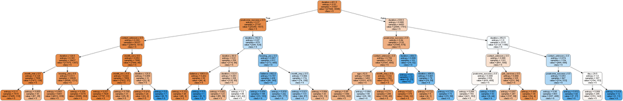

```python
dot_data = StringIO()
export_graphviz(clf_pruned, out_file=dot_data,
                filled=True, rounded=True,
                special_characters=True,feature_names = features,class_names=['5','6','8'])
graph = pydotplus.graph_from_dot_data(dot_data.getvalue())
graph.write_png('wines_pruned.png')
Image(graph.create_png())
```

```python
preds_train = clf_pruned.predict(X_train)
preds_test = clf_pruned.predict(X_test)

acc_DT = accuracy_score(y_test, preds_test)
rec_DT = recall_score(y_test, preds_test)
pre_DT = precision_score(y_test, preds_test)
```

### Decision tree performance

```python
# Confusion matrix
pd.crosstab(y_test, preds_test, rownames=['Actual'], colnames=['Predicted'])
```

| Predicted Actual | 0 | 1 |
| --- | --- | --- |
| 0 | 11745 | 228 |
| 1 | 1121 | 470 |

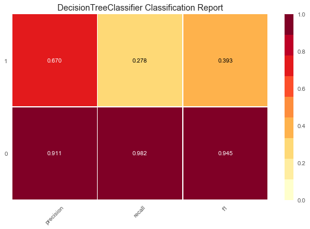

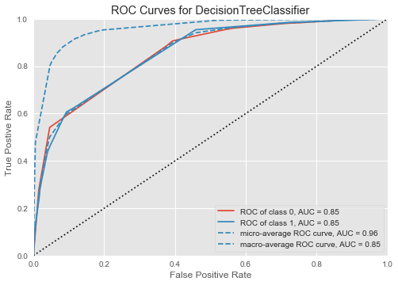

```python
# Visualize model performance with yellowbrick library
viz = ClassificationReport(DecisionTreeClassifier(criterion = "entropy", max_depth=4))
viz.fit(X_train, y_train)
viz.score(X_test, y_test)
viz.show()

roc = ROCAUC(DecisionTreeClassifier(criterion = "entropy", max_depth=4))
roc.fit(X_train, y_train)
roc.score(X_test, y_test)
roc.show();
```

```python
## Calculating feature importance

feat_importance = clf_pruned.tree_.compute_feature_importances(normalize=False)


feat_imp_dict = dict(zip(features, clf_pruned.feature_importances_))
feat_imp = pd.DataFrame.from_dict(feat_imp_dict, orient='index')
feat_imp.sort_values(by=0, ascending=False)
```

|  | 0 |
| --- | --- |
| duration | 0.5414 |
| poutcome_success | 0.2576 |
| contact_unknown | 0.1089 |
| housing_yes | 0.0546 |
| month_mar | 0.0140 |
| month_oct | 0.0075 |
| month_nov | 0.0046 |
| month_may | 0.0041 |
| age | 0.0033 |
| balance | 0.0015 |
| day | 0.0013 |
| job_services | 0.0011 |
| month_sep | 0.0000 |
| month_dec | 0.0000 |
| default_yes | 0.0000 |
| loan_yes | 0.0000 |
| contact_telephone | 0.0000 |
| month_jun | 0.0000 |
| month_jul | 0.0000 |
| month_jan | 0.0000 |
| poutcome_other | 0.0000 |
| month_feb | 0.0000 |
| education_unknown | 0.0000 |
| month_aug | 0.0000 |
| job_self-employed | 0.0000 |
| campaign | 0.0000 |
| job_blue-collar | 0.0000 |
| job_entrepreneur | 0.0000 |
| job_housemaid | 0.0000 |
| job_management | 0.0000 |
| job_retired | 0.0000 |
| job_student | 0.0000 |
| education_tertiary | 0.0000 |
| job_technician | 0.0000 |
| job_unemployed | 0.0000 |
| job_unknown | 0.0000 |
| marital_married | 0.0000 |
| marital_single | 0.0000 |
| education_secondary | 0.0000 |
| poutcome_unknown | 0.0000 |

#### From the feature importance dataframe we can infer that duration, poutcome_success, contact, housing, month, age, balance, day and job are important features.

```python
#Store the accuracy results for each model in a dataframe for final comparison
tempResultsDf = pd.DataFrame({'Method':['Decision Tree'], 'accuracy': acc_DT, 'precision': pre_DT, 'recall' : rec_DT })
resultsDf = pd.concat([resultsDf, tempResultsDf])
resultsDf = resultsDf[['Method', 'accuracy', 'precision', 'recall']]
resultsDf
```

|  | Method | accuracy | precision | recall |
| --- | --- | --- | --- | --- |
| 0 | Logistic Regression | 0.8991 | 0.6289 | 0.3419 |
| 0 | Decision Tree | 0.9005 | 0.6734 | 0.2954 |

### Applying the Random forest model

```python
from sklearn.ensemble import RandomForestClassifier
rfcl = RandomForestClassifier(n_estimators = 50)
rfcl = rfcl.fit(X_train, y_train)
```

```python
pred_RF = rfcl.predict(X_test)
acc_RF = accuracy_score(y_test, pred_RF)
pre_RF = precision_score(y_test, pred_RF)
rec_RF = recall_score(y_test, pred_RF)
```

```python
tempResultsDf = pd.DataFrame({'Method':['Random Forest'], 'accuracy': [acc_RF], 'precision': pre_RF, 'recall' : rec_RF})
resultsDf = pd.concat([resultsDf, tempResultsDf])
resultsDf = resultsDf[['Method', 'accuracy', 'precision', 'recall']]
resultsDf
```

|  | Method | accuracy | precision | recall |
| --- | --- | --- | --- | --- |
| 0 | Logistic Regression | 0.8991 | 0.6289 | 0.3419 |
| 0 | Decision Tree | 0.9005 | 0.6734 | 0.2954 |
| 0 | Random Forest | 0.9029 | 0.6526 | 0.3683 |

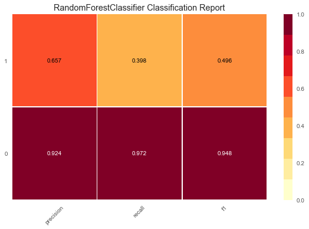

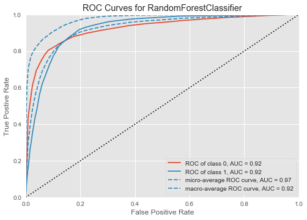

```python
# Visualize model performance with yellowbrick library
viz = ClassificationReport(RandomForestClassifier(n_estimators = 50))
viz.fit(X_train, y_train)
viz.score(X_test, y_test)
viz.show()

roc = ROCAUC(RandomForestClassifier(n_estimators = 50))
roc.fit(X_train, y_train)
roc.score(X_test, y_test)
roc.show()
```

## Applying Adaboost Ensemble Algorithm.

```python
from sklearn.ensemble import AdaBoostClassifier
abcl = AdaBoostClassifier(n_estimators = 100, learning_rate=0.1, random_state=22)
abcl = abcl.fit(X_train, y_train)
```

```python
pred_AB =abcl.predict(X_test)
acc_AB = accuracy_score(y_test, pred_AB)
pre_AB = precision_score(y_test, pred_AB)
rec_AB = recall_score(y_test, pred_AB)
```

```python
tempResultsDf = pd.DataFrame({'Method':['Adaboost'], 'accuracy': [acc_AB], 'precision': pre_AB, 'recall' : rec_AB})
resultsDf = pd.concat([resultsDf, tempResultsDf])
resultsDf = resultsDf[['Method', 'accuracy', 'precision', 'recall']]
resultsDf
```

|  | Method | accuracy | precision | recall |
| --- | --- | --- | --- | --- |
| 0 | Logistic Regression | 0.8991 | 0.6289 | 0.3419 |
| 0 | Decision Tree | 0.9005 | 0.6734 | 0.2954 |
| 0 | Random Forest | 0.9029 | 0.6526 | 0.3683 |
| 0 | Adaboost | 0.8950 | 0.6555 | 0.2212 |

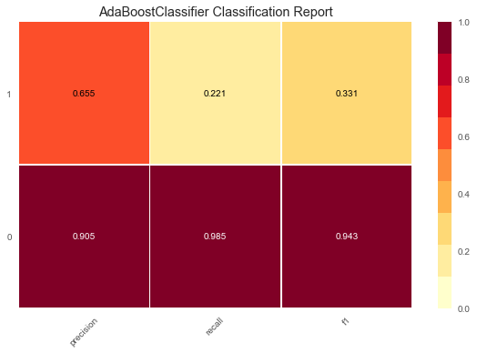

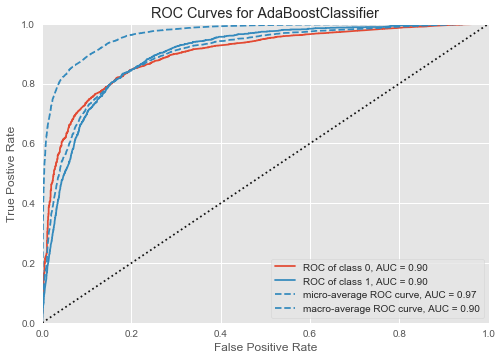

```python
# Visualize model performance with yellowbrick library
viz = ClassificationReport(AdaBoostClassifier(n_estimators= 100, learning_rate=0.1, random_state=22))
viz.fit(X_train, y_train)
viz.score(X_test, y_test)
viz.show()

roc = ROCAUC(AdaBoostClassifier(n_estimators= 100, learning_rate=0.1, random_state=22))
roc.fit(X_train, y_train)
roc.score(X_test, y_test)
roc.show();
```

### Applying Bagging Classifier Algorithm

```python
from sklearn.ensemble import BaggingClassifier

bgcl = BaggingClassifier(n_estimators=50, max_samples= .7, bootstrap=True, oob_score=True, random_state=22)
bgcl = bgcl.fit(X_train, y_train)
```

```python
pred_BG = bgcl.predict(X_test)
acc_BG = accuracy_score(y_test, pred_BG)
pre_BG = precision_score(y_test, pred_BG)
rec_BG = recall_score(y_test, pred_BG)
```

```python
tempResultsDf = pd.DataFrame({'Method':['Bagging'], 'accuracy': [acc_BG], 'precision': pre_BG,'recall': rec_BG})
resultsDf = pd.concat([resultsDf, tempResultsDf])
resultsDf = resultsDf[['Method', 'accuracy', 'precision', 'recall']]
resultsDf
```

|  | Method | accuracy | precision | recall |
| --- | --- | --- | --- | --- |
| 0 | Logistic Regression | 0.8991 | 0.6289 | 0.3419 |
| 0 | Decision Tree | 0.9005 | 0.6734 | 0.2954 |
| 0 | Random Forest | 0.9029 | 0.6526 | 0.3683 |
| 0 | Adaboost | 0.8950 | 0.6555 | 0.2212 |
| 0 | Bagging | 0.9015 | 0.6093 | 0.4469 |

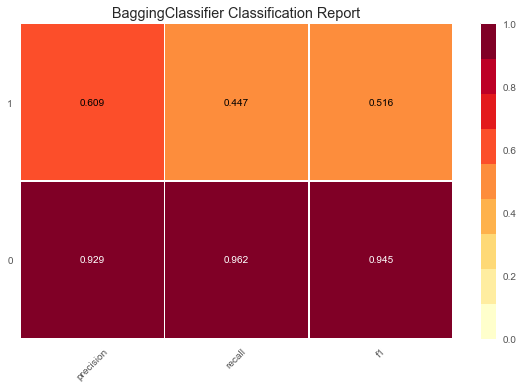

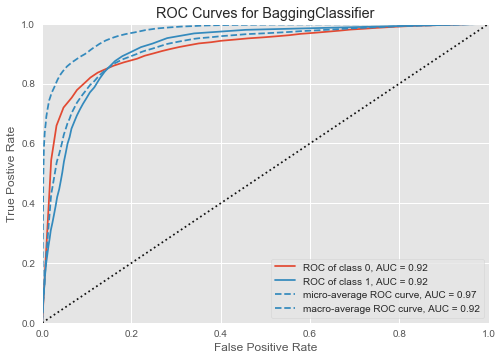

```python
# Visualize model performance with yellowbrick library
viz = ClassificationReport(BaggingClassifier(n_estimators=50, max_samples= .7, bootstrap=True, oob_score=True, random_state=22))
viz.fit(X_train, y_train)
viz.score(X_test, y_test)
viz.show()

roc = ROCAUC(BaggingClassifier(n_estimators=50, max_samples= .7, bootstrap=True, oob_score=True, random_state=22))
roc.fit(X_train, y_train)
roc.score(X_test, y_test)
roc.show();
```

### Applying GradientBoost Classifier Algorithm

```python
from sklearn.ensemble import GradientBoostingClassifier
gbcl = GradientBoostingClassifier(n_estimators = 50, learning_rate = 0.1, random_state=22)
gbcl = gbcl.fit(X_train, y_train)
```

```python
pred_GB = gbcl.predict(X_test)
acc_GB = accuracy_score(y_test, pred_GB)
pre_GB = precision_score(y_test, pred_GB)
rec_GB = recall_score(y_test, pred_GB)
```

```python
tempResultsDf = pd.DataFrame({'Method':['Gradient Boost'], 'accuracy': [acc_GB], 'precision': pre_GB, 'recall': rec_GB})
resultsDf = pd.concat([resultsDf, tempResultsDf])
resultsDf = resultsDf[['Method', 'accuracy', 'precision', 'recall']]
resultsDf
```

|  | Method | accuracy | precision | recall |
| --- | --- | --- | --- | --- |
| 0 | Logistic Regression | 0.8991 | 0.6289 | 0.3419 |
| 0 | Decision Tree | 0.9005 | 0.6734 | 0.2954 |
| 0 | Random Forest | 0.9029 | 0.6526 | 0.3683 |
| 0 | Adaboost | 0.8950 | 0.6555 | 0.2212 |
| 0 | Bagging | 0.9015 | 0.6093 | 0.4469 |
| 0 | Gradient Boost | 0.9031 | 0.6576 | 0.3633 |

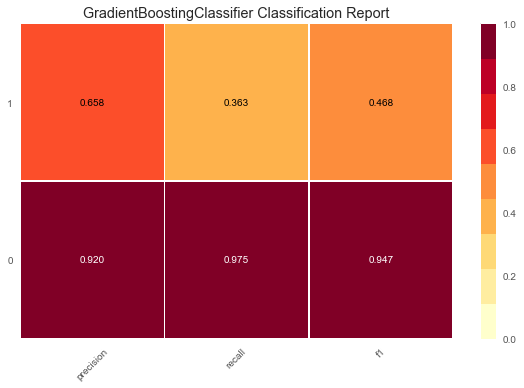

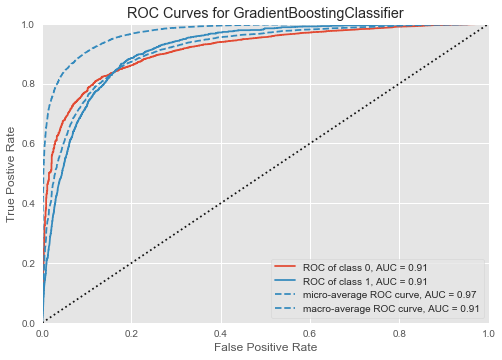

```python
# Visualize model performance with yellowbrick library
viz = ClassificationReport(GradientBoostingClassifier(n_estimators = 50, learning_rate = 0.1, random_state=22))
viz.fit(X_train, y_train)
viz.score(X_test, y_test)
viz.show()

roc = ROCAUC(GradientBoostingClassifier(n_estimators = 50, learning_rate = 0.1, random_state=22))
roc.fit(X_train, y_train)
roc.score(X_test, y_test)
roc.show();
```

### Applying XGboost Classifier Algorithm for the same data

```python
from xgboost import XGBClassifier
```

```python
xgb_model = XGBClassifier(random_state=42)
xgb_model.fit(X_train, y_train)
```

```
XGBClassifier(base_score=0.5, booster='gbtree', colsample_bylevel=1,
       colsample_bytree=1, gamma=0, learning_rate=0.1, max_delta_step=0,
       max_depth=3, min_child_weight=1, missing=None, n_estimators=100,
       n_jobs=1, nthread=None, objective='binary:logistic',
       random_state=42, reg_alpha=0, reg_lambda=1, scale_pos_weight=1,
       seed=None, silent=True, subsample=1)
```

```python
pred_XGB = gbcl.predict(X_test)
acc_XGB = accuracy_score(y_test, pred_XGB)
pre_XGB = precision_score(y_test, pred_XGB)
rec_XGB = recall_score(y_test, pred_XGB)
```

```python
tempResultsDf = pd.DataFrame({'Method':['XGboost'], 'accuracy': acc_XGB, 'precision': pre_XGB, 'recall': rec_XGB})
resultsDf = pd.concat([resultsDf, tempResultsDf])
resultsDf = resultsDf[['Method', 'accuracy', 'precision', 'recall']]
resultsDf
```

[output not shown]

#### For this dataset, Bagging model seems to be performing the best. With a recall of 44.6% it out performs the other models. For this problem the recall is of utmost importance predicting out of all the possible customers what fraction did we identify